# What’s going on in the elevator?

I observed aspects of the elevator experience and student tendencies in the school library.

## What floors are you likely to stop at?

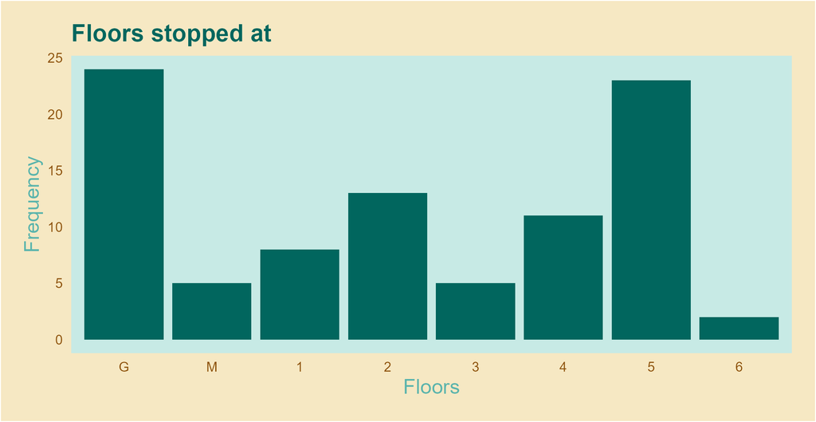

Frequency of floors visited

Here you can get a general idea of how long you’ll be in the elevator. I usually go between the ground floor and floor 5, with a stop or two along the way.

## How busy can you expect the elevator to be through the day?

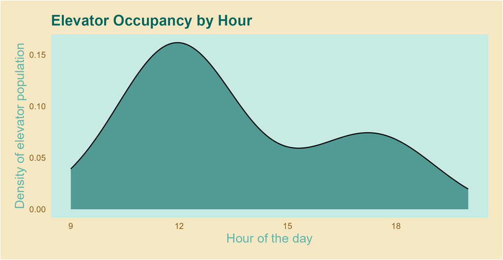

Density of people throughout the day

Maybe you don’t have time to waste! Here you can see when the elevator will be most crowded, making it more likely you will stop at intermediate floors along the way.

## Now let’s see how these factors will change people’s tendency to check their phones

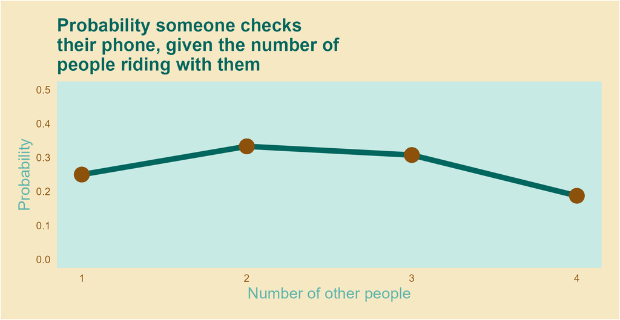

Chances someone checks their phone depending on how many other people are in the elevator

I want to look at how the number of people in the elevator effects the chances that the average person will check their phone. A busier ride implies a longer journey and a more confined space. I’ve plotted the chance that anyone checks their phone divided by the number of people in the elevator to see if the average person is more likely to pass the time with a screen if there are more people present. I’m surprised to see that this doesn’t look like it is the case.